# Project_2_Dataset_3_Fox

Author

Amanda Fox

Published

March 3, 2024

### Intro

Gross “food production” data across many categories has been collected nationally since the 1860s. Post-WWII, this data was refined to “food available for consumption” by removing pre-consumer uses and waste, and estimated back to 1909 in the case of this liquid milk dataset. Note that an even more refined estimate of “consumption” can be calculated by removing estimated retail and consumer waste, but this data is more limited and comes with caveats due to the estimation involved.

Food is necessary to all societies regardless of time or place, and so there are many interesting trends and nuances in national food supply data that provide evidence of other social and economic changes.

Among a wealth of other data, the USDA economic research service (ERS) publishes a dataset of United States per capita fluid milk consumer availability since 1909 (https://www.ers.usda.gov/webdocs/DataFiles/50472/dyfluid.xlsx?v=8029.7).

In this exercise, I analyzed this dataset as follows:

1. Total availability trends for three types of fluid milk products 1909 to present
2. Shift between “consumed where produced” vs. available for sale from 1909 to present
3. Estimated consumption trends since 1970 by applying the current retail + consumer food waste estimate of 32% (USDA ERS - Loss-Adjusted Food Availability Documentation)

First I loaded the libraries:

```r
# -------- Load libraries

library(tidyverse)
library(dplyr)
library(ggplot2)
library(scales)
library(RColorBrewer)
```

Then I loaded the main data table, skipping rows at the top where column names were merged across multiple columns and wrapped onto multiple rows. I renamed all columns, removed the footer rows, and changed the years to numeric to use in my charts later.

```r
df <- read_csv("https://raw.githubusercontent.com/AmandaSFox/DATA607/main/project_2/Dataset_3_Milk/fluid_milk_gallons.csv",
               skip = 6)
```

```
──────────────────────────────────────────────────────── Delimiter: "," chr
(2): ...1, ...17 dbl (19): --- Millions ----,
-----------------------------------------------...
```

```r
colnames(df) <- c("yr","pop","whole_plain_cons","whole_plain_sales","whole_plain_tot",
                 "whole_flav","tot_whole","low_2_pct","low_1_pct","low_tot_plain","low_flav",
                 "low_subtot_plain_flav","buttermilk","skim","skim_buttermilk_cons",
                 "tot_low_skim_all","other_eggnog","other_misc","tot_other",
                 "tot_bev_sales","tot_bev_avail")

df <- filter(df, yr %in% (1909:2021))

df$yr<-as.numeric(df$yr)
```

This table contained a lot of detail and multiple cuts of the data (types and subtypes of beverages, some split into whether they were consumed at point of production or not).

For ease of analysis, I created a summary table with only the columns I needed, including a new “all other” category, and checked totals:

```r
df_tidy_wide <- df %>%
  select(yr,pop,tot_whole,tot_low_skim_all,tot_bev_sales, tot_bev_avail) %>%
  mutate(tot_other = tot_bev_avail - tot_whole - tot_low_skim_all,
         tot_consumed_on_site = tot_bev_avail - tot_bev_sales) %>%
  select(yr,pop,tot_whole,tot_low_skim_all,tot_other,tot_bev_avail,
         tot_bev_sales,tot_consumed_on_site
         )

# check totals
test <- df_tidy_wide %>%
  summarize(sum(tot_whole), sum(tot_low_skim_all), sum(tot_other), sum(tot_consumed_on_site),
            sum(tot_bev_avail), sum(tot_bev_sales)
            )
```

This resulting table is clean and, with one observation per row (year), tidy for analysis including trends by year with comparisons across categories (e.g. some tibbles with % totals shown below).

For other analysis including charts, I also needed to create a long tidy table with one observation equaling one year/category pair, by melting the category variables from column headers to rows, as follows:

```r
df_tidy <- df_tidy_wide %>%
  pivot_longer(cols = c(2:8),
               names_to = "category",
               values_to = "gallons"
               )
```

### 1. Total availability trends for three types of fluid milk products 1909 to present

With the data now clean and tidied, I created a summary table and plotted the long term trends 1909-2021 for major categories of beverages by type, regardless if consumed on location or made available for sale: whole (plain and flavored), low fat (includes skim), and other (buttermilk, the milk component of eggnog, etc.).

```r
df_wwii <- filter(df_tidy, yr %in% (1939:1948), category == "tot_bev_avail")
df_wwii
```

```
# A tibble: 10 × 3
      yr category      gallons
   <dbl> <chr>           <dbl>
 1  1939 tot_bev_avail    34
 2  1940 tot_bev_avail    34
 3  1941 tot_bev_avail    34.4
 4  1942 tot_bev_avail    37
 5  1943 tot_bev_avail    41
 6  1944 tot_bev_avail    43.6
 7  1945 tot_bev_avail    44.7
 8  1946 tot_bev_avail    42.1
 9  1947 tot_bev_avail    39.9
10  1948 tot_bev_avail    38.1
```

The overall downward trend after WWII was precipitous: from the peak of 44.7 gallons per capita in 1945, availability descended to its lowest point of 15.6 gallons in 2021, the latest year reported in this dataset.

```r
# -------- line trend #1 whole vs total

# Display data table: create wide tidy format, one obs = one year, to calc % trends

df_avail_type <- filter(df_tidy, category %in% c("tot_whole", "tot_low_skim_all","tot_other"))


df_type_sum <- filter(df_avail_type, yr %in% c(1920,1940,1960,1980,2000,2020)) %>%
  pivot_wider(names_from = category,values_from = gallons) %>%
  mutate(percent_whole = tot_whole/(tot_whole + tot_low_skim_all + tot_other),
       percent_low_skim = tot_low_skim_all/(tot_whole + tot_low_skim_all + tot_other),
       percent_other = tot_other/(tot_whole + tot_low_skim_all + tot_other))
df_type_sum
```

```
# A tibble: 6 × 7
     yr tot_whole tot_low_skim_all tot_other percent_whole percent_low_skim
  <dbl>     <dbl>            <dbl>     <dbl>         <dbl>            <dbl>
1  1920      28.1              5.9 -1.78e-15         0.826           0.174
2  1940      29.2              4.7  1.00e- 1         0.859           0.138
3  1960      31.2              2.7 -8.88e-16         0.920           0.0796
4  1980      17               10.5  1.00e- 1         0.616           0.380
5  2000       8.2             14.5  1.00e- 1         0.360           0.636
6  2020       6.2              9.8  3.00e- 1         0.380           0.601
# ℹ 1 more variable: percent_other <dbl>
```

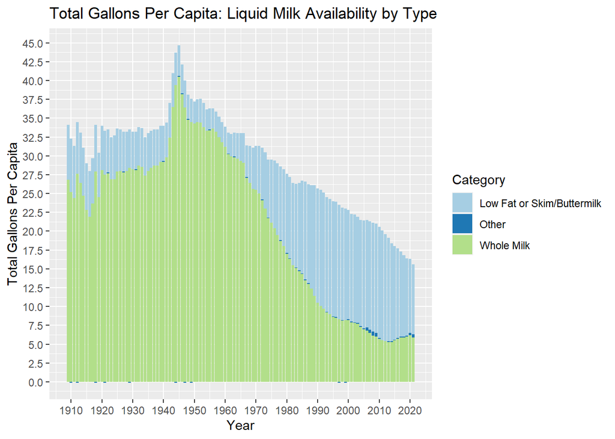

```r
# Create plot: long tidy dataframe, one obs = one year/category pair

ggplot(df_avail_type, aes(x = yr, y = gallons, fill = category)) +
  geom_bar(stat="identity") +
  scale_fill_brewer(palette = "Paired", name = "Category",
                    labels = c("Low Fat or Skim/Buttermilk","Other","Whole Milk")
                    ) +
  scale_x_continuous(breaks = breaks_width(10))+
  scale_y_continuous(n.breaks=20, labels = scales::label_comma()) +
  xlab("Year") +
  ylab("Total Gallons Per Capita") +
  ggtitle("Total Gallons Per Capita: Liquid Milk Availability by Type")
```

### 2. Shift between “consumed where produced” vs. available for sale from 1909 to present

The next analysis was performed on the relationship between milk consumed at the point of production vs. available for sale. Note that in 1920, almost half (46.8%) of liquid milk products was consumed at the point of production, which fell to less than 10% by 1960 and was no longer reported in 2020.

Interestingly, the total gallons per capital available for sale in 2020 was less than that in 1920, when 46.8% of the milk produced was consumed at point of production and excluded from this metric.

```r
df_avail_con <- filter(df_tidy, category %in% c("tot_consumed_on_site","tot_bev_sales"))

# Display data table: create a wide tidy format, one obs = one year, to calc % trends

df_avail_sum <- filter(df_avail_con, yr %in% c(1920,1940,1960,1980,2000,2020)) %>%
  pivot_wider(names_from = category,values_from = gallons) %>%
  mutate(percent_consumed_on_site = tot_consumed_on_site/(tot_consumed_on_site + tot_bev_sales))

df_avail_sum
```

```
# A tibble: 6 × 4
     yr tot_bev_sales tot_consumed_on_site percent_consumed_on_site
  <dbl>         <dbl>                <dbl>                    <dbl>
1  1920          18.1               15.9                    0.468
2  1940          21                 13                      0.382
3  1960          30.7                3.2                    0.0944
4  1980          27.1                0.5                    0.0181
5  2000          22.7                0.100                  0.00439
6  2020          16.3                0                      0
```

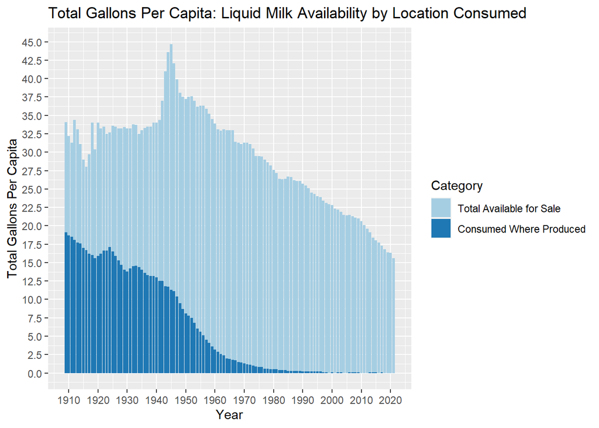

```r
# Create plot: long tidy dataframe, one obs = one year/category pair

ggplot(df_avail_con, aes(x = yr, y = gallons, fill = category)) +
  geom_bar(stat="identity") +
  scale_fill_brewer(palette = "Paired", name = "Category", labels = c("Total Available for Sale","Consumed Where Produced")) +
  scale_x_continuous(breaks = breaks_width(10))+
  scale_y_continuous(n.breaks=20, labels = scales::label_comma()) +
  xlab("Year") +
  ylab("Total Gallons Per Capita") +
  ggtitle("Total Gallons Per Capita: Liquid Milk Availability by Location Consumed")
```

### 3. Estimated consumption per capita trend

As mentioned in the introduction, the USDA provides broad estimates of post-production (retail and consumer) waste, in order to estimate loss-adjusted availability, a proxy for what we might call actual consumption.

There are multiple caveats to this estimate, as this data is complex and rarely tracked (when was the last time you weighed your food waste?). Extensive documentation is available here: https://www.ers.usda.gov/data-products/food-availability-per-capita-data-system/loss-adjusted-food-availability-documentation/#usefulness

This data is hard to obtain but quite valuable in understanding not only patterns of waste but also patterns in actual American nutrition compared to recommendations or to historical patterns (example study summary: https://www.ers.usda.gov/webdocs/publications/82220/eib166%20summary.pdf?v=4270.2).

The USDA provides a current estimate of 32% retail + consumer waste for dairy products overall. Assuming that this (1) applies to liquid milk and (2) applies equally across our time period 1970-2021, we find the following trend:

```r
df_avail_adj <- filter(df_avail_con, yr %in% c(1970,1980,1990,2000,2010,2020)) %>%
  pivot_wider(names_from = category,values_from = gallons) %>%
  mutate(tot_avail = tot_consumed_on_site + tot_bev_sales, loss_adjusted_avail = .68 * tot_avail)

df_avail_adj
```

```
# A tibble: 6 × 5
     yr tot_bev_sales tot_consumed_on_site tot_avail loss_adjusted_avail
  <dbl>         <dbl>                <dbl>     <dbl>               <dbl>
1  1970          30                  1.3        31.3                21.3
2  1980          27.1                0.5        27.6                18.8
3  1990          25.5                0.200      25.7                17.5
4  2000          22.7                0.100      22.8                15.5
5  2010          20.6                0          20.6                14.0
6  2020          16.3                0          16.3                11.1
```

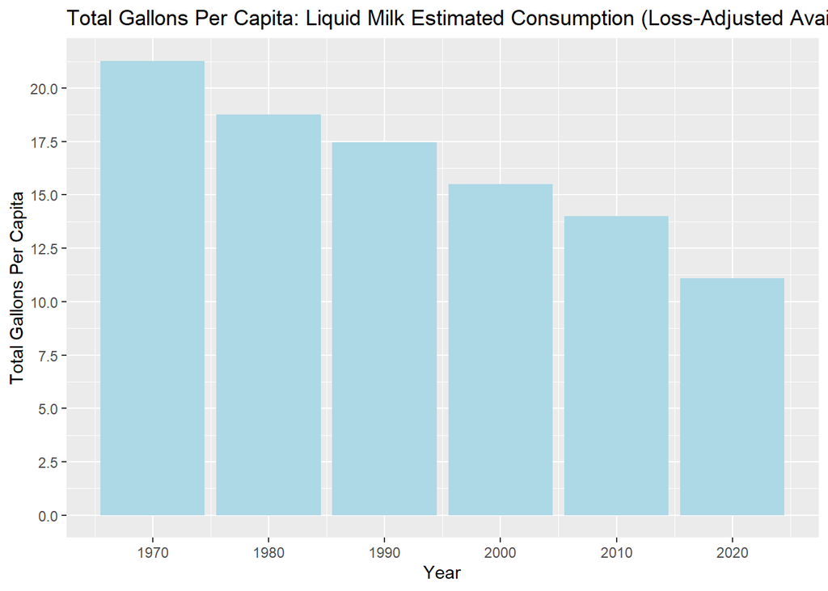

```r
# Create plot:

ggplot(df_avail_adj, aes(x = yr, y = loss_adjusted_avail)) +
  geom_bar(stat="identity", fill = "lightblue") +
  scale_x_continuous(breaks = breaks_width(10))+
  scale_y_continuous(n.breaks=11, labels = scales::label_comma()) +
  xlab("Year") +
  ylab("Total Gallons Per Capita") +
  ggtitle("Total Gallons Per Capita: Liquid Milk Estimated Consumption (Loss-Adjusted Availability)")
```

While this chart of course tracks the previously-seen aggregate trends, it does add relatable context: Americans are now drinking less than one gallon per person per month, whereas in 1970, we were drinking nearly two gallons per person per month.